# Повний курс по HTML тегам з прикладами.

### Copyright © Yaroslav Andreiev

## 1. Коментарі в HTML файлі

### Коментарі потрібні для того, щоб програмісту було легше читати код/розмітку. Наприклад ви створюєте блок меню. З допомогою коментаря можемо позначити те, що в даній частині розмітки ви пишете меню. Писання коментарів є особливо популярним якщо ви програмуєте в команді. Інші члени команди зможуть краще розуміти ваші зміни.

```python
# Синтаксис: <!--Це приклад коментаря в HTML-->
```

[figure not shown]

## 2. Посилання. Перехід на ресурс при нажиманні на текст

### Створення посилань на сайті є важливою частиною, оскільки таким чином ми зможемо переходити на різні веб-сайти та ресурси.

```python
# Синтаксис: <a href="https://www.youtube.com/?hl=uk&gl=UA">Visit Youtube</a>
```

# Приклад:

[Visit Youtube](https://www.youtube.com/?hl=uk&gl=UA)

[figure not shown]

## 2.1 Атрибут target HTML тега a

### Атрибут target визначає, де відкривати документ, на який веде посилання.

```python
# Синтаксис: <a href="https://www.youtube.com/?hl=uk&gl=UA target="_blank">Visit Youtube</a>
```

# Приклад:

[Visit Youtube](https://www.youtube.com/?hl=uk&gl=UA)

- target="_self" відкриває в тому самому вікні

## 3. Зображення

### Зображення є одним з найважливіших елементів сайтів, оскільки вони зустрічаються дуже часто та задають дизайн, настрій та контент сайту.

```python
# Синтаксис: <img src="exampleImg.jpg" alt="Example">
```

[figure not shown]

### Звернемо увагу на те, що зображення повинно знаходитись в одній папці з сайтом, щоб в src писати лише його назву. Якщо ж зображення наприклад знаходить в папці з назвою img тоді src="img/exampleImg.jpg".

### Приклади шляхів до файлів можна прочитати ось тут https://www.w3schools.com/html/html_filepaths.asp

## 3.1 Атрибути width та height

### Зображення мають різну ширину та висоту. Ми можемо її задавати прямо в тегу img.

```python
 # Синтаксис: <img src="img_girl.jpg" alt="Girl in a jacket" width="500" height="600">
```

## 4. Заголовки

### Заголовки є важливим елементом, оскільки вони повинні привертати увагу, коротко доносити інформацію, робити "бренд" сайту. Зазвичай в заголовках пишуть назву сайту, товару, бренду і т.д. Заголовки позначаються парними тегами h1,h2,h3,h4,h5,h6

```python
 # Синтаксис: <h1>Заголовок розміру 1</h1>
```

[figure not shown]

# Текст різного розміру 1

## Текст різного розміру 2

### Текст різного розміру 3

#### Текст різного розміру 4

##### Текст різного розміру 5

###### Текст різного розміру 6

## 5. Горизонтальна лінія hr

### Такого типу лінію використовують щод відділити один контент від іншого

```python
 # Синтаксис: <hr>
```

## 5.1 Атрибут size тегу hr

### Size регулює розмір лінії

```python
# Синтаксис: <hr size="число">
```

## 6. Тег введення input

### Головним чином input призначений для створення текстових полів, різних кнопок, перемикачів і прапорців.

За допомогою HTML тегу input можна створити наступну елементи форми (За це відповідає атрибут type):

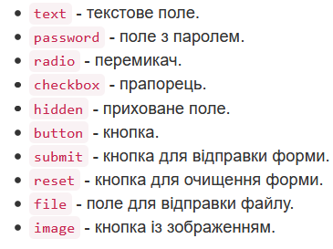

```python
'''
  <p><b>Ваше ім'я:</b><br>
   <input type="text" size="40">
  </p>
  <p><b>Яким браузером ви користуєтесь?:</b><Br>
   <input type="radio" name="browser" value="ie"> Internet Explorer<Br>
   <input type="radio" name="browser" value="opera"> Opera<Br>
   <input type="radio" name="browser" value="firefox"> Firefox<Br>
  </p>
  <p>Коментар<Br>
   <textarea name="comment" cols="40" rows="3"></textarea></p>
  <p><input type="submit" value="Відправити">
   <input type="reset" value="Очистити"></p>
'''
```

## Приклад коду, що наведено вище:

**Ваше ім'я:**

**Яким браузером ви користуєтесь?:**  
Internet Explorer  
Opera  
Firefox

Коментар

## 7. HTML тег audio відтворює аудіозапис і керує ним на веб-сторінці

### Музика є важливою на сайтах про музичні чарти, мистецтво та платформах типу Spotify. Класно також можна використати цей тег у випадку коли на сайті потрібно програвати музику на фоні

```python
'''
<audio controls>
  <source src="https://www.w3schools.com/html/horse.ogg"  type="audio/ogg">
  <source src="https://www.w3schools.com/html/horse.mp3"  type="audio/mpeg">
    Ваш браузер не підтримує фотмат даних аудіо фвйлів.
</audio>
'''
```

## 8. HTML тег !DOCTYPE

### !DOCTYPE призначений для задання типу поточного документа - DTD (document type definition, опис типу документа).

### Він повинен бути першим елементом в вашому html-документі, він повинен йти перед тегом html

```python
# Синтаксис: <!DOCTYPE html>
```

[figure not shown]

## 9. Тег big

### Тег big збільшує розмір шрифту на одиницю в порівнянні зі звичайним текстом. Таким чином, додавання тега big збільшує текст на одну умовну одиницю. Допускається застосування вкладених тегів big, при цьому розмір шрифту буде більше з кожним рівнем

```python
# Синтаксис: <h3>Приклад з використанням  тегу <code>big</code></h3>
```

## Приклад коду, що наведено вище:

### Приклад з використанням тегу `big`